# Classification

Nathan Butler!

02/24/2025

**Abstract:**

This is a technical blog post of **both** an HTML file *and* [.qmd file](https://raw.githubusercontent.com/cd-public/D505/refs/heads/master/hws/src/classify.qmd) hosted on GitHub pages.

# 0. Quarto Type-setting

- This document is rendered with Quarto, and configured to embed an images using the `embed-resources` option in the header.
- If you wish to use a similar header, here’s is the format specification for this document:

```
format:
  html:
    embed-resources: true
```

# 1. Setup

**Set Up Code:**

```r
sh <- suppressPackageStartupMessages
sh(library(tidyverse))
sh(library(caret))
sh(library(naivebayes))
wine <- readRDS(gzcon(url("https://github.com/cd-public/D505/raw/master/dat/pinot.rds")))
```

# 2. Logistic Concepts

Why do we call it Logistic Regression even though we are using the technique for classification?

> TODO: *We call it this because Logistic Regression models the log odds of the outcome as a linear combination of the input variables. This is different from classification which makes a direct True/False output. A logistic regression produces a probability between 0 and 1*

# 3. Modeling

We train a logistic regression algorithm to classify a whether a wine comes from Marlborough using:

```r
pacman::p_load(tidytext,data.table,scales,pROC)
data(stop_words)
head(stop_words, 25)$word
```

```
##  [1] "a"           "a's"         "able"        "about"       "above"
##  [6] "according"   "accordingly" "across"      "actually"    "after"
## [11] "afterwards"  "again"       "against"     "ain't"       "all"
## [16] "allow"       "allows"      "almost"      "alone"       "along"
## [21] "already"     "also"        "although"    "always"      "am"
```

```r
wino <- wine %>%
  unnest_tokens(word, description)
head(wino)
```

```
##   id province price points year     word
## 1  1   Oregon    65     87 2012     much
## 2  1   Oregon    65     87 2012     like
## 3  1   Oregon    65     87 2012      the
## 4  1   Oregon    65     87 2012  regular
## 5  1   Oregon    65     87 2012 bottling
## 6  1   Oregon    65     87 2012     from
```

```r
wino <- wino %>%
  anti_join(stop_words)
wino <- wino %>%
  filter(!(word %in% c("wine","pinot","drink","noir","vineyard","palate","notes","flavors","bottling")))
head(wino)
```

```
##   id province price points year    word
## 1  1   Oregon    65     87 2012 regular
## 2  1   Oregon    65     87 2012    2012
## 3  1   Oregon    65     87 2012   rough
## 4  1   Oregon    65     87 2012  tannic
## 5  1   Oregon    65     87 2012  rustic
## 6  1   Oregon    65     87 2012  earthy
```

```r
wino %>%
  filter(province == "Marlborough") %>%
  count(province, word) %>%
  group_by(province) %>%
  top_n(5, n) %>%
  arrange(province, desc(n)) %>%
  head()
```

```
## # A tibble: 5 × 3
## # Groups:   province [1]
##   province    word       n
##   <chr>       <chr>  <int>
## 1 Marlborough fruit    129
## 2 Marlborough cherry   127
## 3 Marlborough finish   108
## 4 Marlborough bodied    83
## 5 Marlborough medium    77
```

```r
wino_marl <- wine %>%
  mutate(
    fruit = as.factor(str_detect(tolower(description), "fruit")),
    cherry = as.factor(str_detect(tolower(description), "cherry")),
    finish = as.factor(str_detect(tolower(description), "finish")),
    bodied = as.factor(str_detect(tolower(description), "bodied")),
    bodied = as.factor(str_detect(tolower(description), "medium")),
    tropical = as.factor(str_detect(tolower(description), "passion fruit|pineapple|guava|tropical")),

    marl = as.factor(province == "Marlborough")
  ) %>%
  select(-c(description,id,province,points,year))
```

```r
set.seed(505)
train_index <- createDataPartition(wino_marl$marl, p = 0.8, list = FALSE)
train_data <- wino_marl[train_index, ]
test_data <- wino_marl[-train_index, ]
```

```r
control = trainControl(method = "cv", number = 5)
get_fit <- function(df) {
  train(marl ~ .,
        data = df,
        trControl = control,
        method = "glm",
        family = "binomial",
        maxit = 5)
}
fit <- get_fit(train_data)
fit
```

```
## Generalized Linear Model
##
## 6705 samples
##    6 predictor
##    2 classes: 'FALSE', 'TRUE'
##
## No pre-processing
## Resampling: Cross-Validated (5 fold)
## Summary of sample sizes: 5363, 5364, 5365, 5364, 5364
## Resampling results:
##
##   Accuracy   Kappa
##   0.9725579  0
```

# 4. Binary vs Other Classification

What is the difference between determining some form of classification through logistic regression versus methods like $K$-NN and Naive Bayes which performed classifications.

> TODO: *Explain: The main difference I see is that Logistic Regression models the relationship between features and the probability of a outcome, however knn and bayes directly classify without explicitly modeling probabilities.*

# 5. ROC Curves

We can display an ROC for the model to explain your model’s quality.

```r
prob <- predict(fit, newdata = test_data, type = "prob")[,2]
myRoc <- roc(test_data$marl, prob)
```

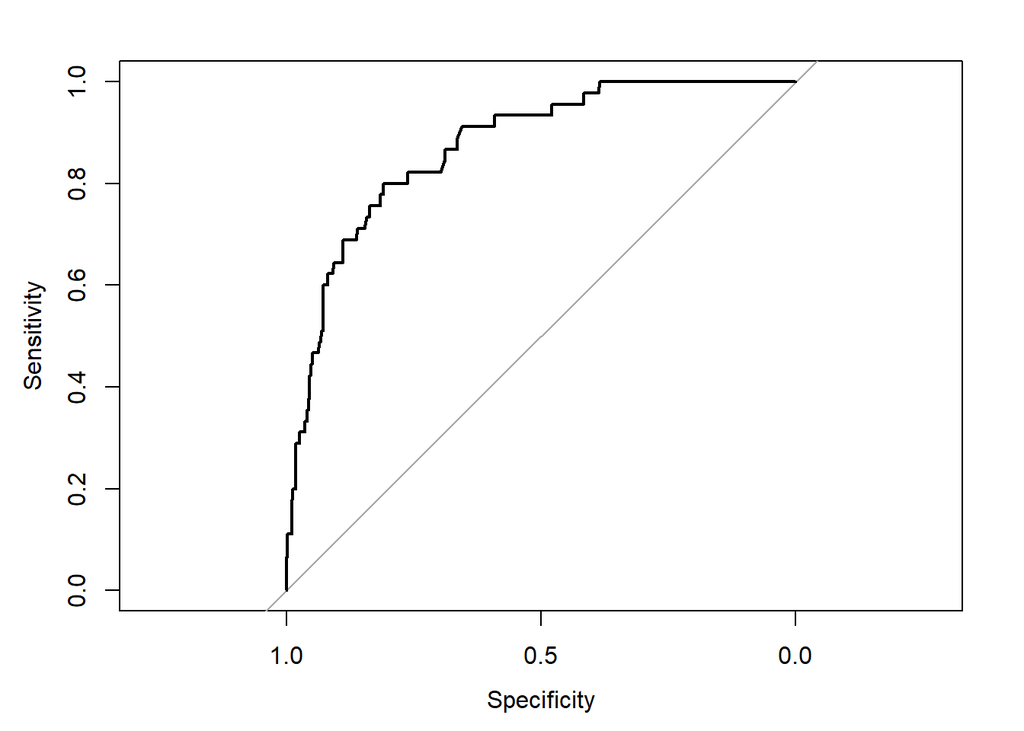

```r
plot(myRoc)
```

```r
auc(myRoc)
```

```
## Area under the curve: 0.8719
```